# Bloque 2: Probabilidad condicional y análisis de datos

# ¿Para qué nos sirve calcular probabilidades?

En el bloque anterior usamos simulaciones para aproximar probabilidades. Lanzamos monedas, repetimos experimentos y observamos cómo las proporciones se estabilizaban cuando aumentaba el número de repeticiones.

Ahora daremos un paso más.

En muchas situaciones reales no trabajamos solo con monedas o dados. Trabajamos con **datos**. A partir de ellos, podemos conocer probabilidades desde la perspectiva frecuentista que vimos en el bloque anterior.

## Un ejemplo: una tabla de doble entrada

Se encuestó a 70 estudiantes sobre dos preguntas:

1. ¿Escuchas música mientras estudias?
2. ¿Usas audífonos mientras estudias?

Los resultados fueron:

|  | Usa audífonos | No usa audífonos | Total |
| --- | --- | --- | --- |
| Escucha música | 32 | 8 | 40 |
| No escucha música | 10 | 20 | 30 |
| **Total** | **42** | **28** | **70** |

## Preguntas

> ¿Cuál es la probabilidad de que una estudiante use audífonos?

> ¿Cuál es la probabilidad de que una estudiante use audífonos, si sabemos que escucha música mientras estudia?

**Para conversar**

¿Cuál es la diferencia entre ambas preguntas?

# Ahora trabajaremos con una base de datos

Hasta ahora usamos una tabla pequeña.

Pero cuando tenemos muchos datos, es más útil usar R.

Trabajaremos con una base de datos en la que se registraron las condiciones de lluevia en algunos días y si la estudiante llevó o no paraguas:

- `llueve`: indica si ese día llovió o no.
- `paraguas`: indica si una estudiante llevó paraguas o no.

A partir de la base de datos, podemos usar la definición de probabilidad frecuentista que vimos en el bloque anterior para responder algunas preguntas como:

1. ¿Cuál es la probabilidad de llevar paraguas?
2. ¿Cuál es la probabilidad de que llueva?
3. ¿Cuál es la probabilidad de llevar paraguas si llueve?

# Cargar una base de datos en R

El archivo que usaremos se llama:

```
paraguas_lluvia.txt
```

Este archivo va adjunto al correo enviado con el link del material del curso, el cual vamos a descargar y guardar en el escritorio del computador.

Para cargar el archivo al computador, vamos a usar la función **read.table**

```r
datos <- read.table("paraguas_lluvia.txt",
                    header = TRUE)
```

¿Qué significa este código?

- `read.table()` le dice a R que queremos leer una tabla.
- `"paraguas_lluvia.txt"` es el nombre del archivo.
- `header = TRUE` indica que la primera fila contiene los nombres de las variables.
- `datos <-` guarda la base de datos con el nombre `datos`.

# Mirar las primeras filas

Para ver las primeras filas usamos:

```r
head(datos)
```

```
  llueve paraguas
1     No       No
2     Sí       Sí
3     No       No
4     Sí       Sí
5     Sí       Sí
6     No       No
```

Cada fila representa un día.

Cada columna representa una variable.

# ¿Cuántas filas y columnas tiene la base?

La función `nrow()` cuenta cuántas filas tiene una base de datos.

```r
nrow(datos)
```

```
[1] 100
```

La función `ncol()` cuenta cuántas columnas tiene una base de datos.

```r
ncol(datos)
```

```
[1] 2
```

**Recordemos**

En esta base:

- cada fila representa un día observado;
- cada columna representa una variable;
- `nrow(datos)` nos dice cuántos días tenemos;
- `ncol(datos)` nos dice cuántas variables tenemos.

# Tabla de frecuencias

Podemos cruzar la información de las variables `llueve` y `paraguas` usando `table()` para obtener las frecuencias de cada categoría de las variables.

```r
table(datos$llueve, datos$paraguas)
```

```
     No Sí
  No 66  5
  Sí  7 22
```

Esta tabla nos muestra cuántos días hay en cada combinación:

- días con lluvia y con paraguas;
- días con lluvia y sin paraguas;
- días sin lluvia y con paraguas;
- días sin lluvia y sin paraguas.

# ¿Qué podemos hacer con la base de datos?

Entre otras cosas, podemos seleccionar sub-grupos de datos con los que nos interesa calcular probabilidades.

Para ello, la función `subset()` permite seleccionar solo algunas filas de una base de datos.

Por ejemplo:

```r
subset(datos, paraguas == "Sí")
```

```
   llueve paraguas
2      Sí       Sí
4      Sí       Sí
5      Sí       Sí
11     Sí       Sí
15     No       Sí
21     Sí       Sí
24     Sí       Sí
26     Sí       Sí
32     Sí       Sí
34     Sí       Sí
50     Sí       Sí
53     Sí       Sí
58     Sí       Sí
65     Sí       Sí
67     Sí       Sí
68     Sí       Sí
69     Sí       Sí
71     Sí       Sí
73     Sí       Sí
84     Sí       Sí
85     No       Sí
86     No       Sí
88     Sí       Sí
89     Sí       Sí
92     No       Sí
94     No       Sí
97     Sí       Sí
```

Este código selecciona solamente los días en que se llevó paraguas.

La estructura general es:

```
subset(base_de_datos, condición)
```

En nuestro ejemplo:

```
subset(datos, paraguas == "Sí")
```

significa:

> tomar la base `datos` y seleccionar solo las filas donde `paraguas` es igual a `"Sí"`.

# Probabilidad de llevar paraguas

Primero calculemos:

> ¿Cuál es la probabilidad de llevar paraguas en un día cualquiera?

Para esto necesitamos contar cuántos días se llevó paraguas.

```r
dias_con_paraguas <- subset(datos, paraguas == "Sí")
dias_con_paraguas
```

```
   llueve paraguas
2      Sí       Sí
4      Sí       Sí
5      Sí       Sí
11     Sí       Sí
15     No       Sí
21     Sí       Sí
24     Sí       Sí
26     Sí       Sí
32     Sí       Sí
34     Sí       Sí
50     Sí       Sí
53     Sí       Sí
58     Sí       Sí
65     Sí       Sí
67     Sí       Sí
68     Sí       Sí
69     Sí       Sí
71     Sí       Sí
73     Sí       Sí
84     Sí       Sí
85     No       Sí
86     No       Sí
88     Sí       Sí
89     Sí       Sí
92     No       Sí
94     No       Sí
97     Sí       Sí
```

La función **nrow** nos permite contar la cantidad de filas de la base de datos:

```r
nrow(dias_con_paraguas)
```

```
[1] 27
```

Ahora dividimos por el total de días.

```r
prob_paraguas <- nrow(dias_con_paraguas) / nrow(datos)

prob_paraguas
```

```
[1] 0.27
```

Esto corresponde a una probabilidad marginal porque usamos toda la base de datos.

# Probabilidad marginal de lluvia

Ahora calculemos:

> ¿Cuál es la probabilidad de que llueva?

```r
dias_con_lluvia <- subset(datos, llueve == "Sí")

prob_lluvia <- nrow(dias_con_lluvia) / nrow(datos)

prob_lluvia
```

```
[1] 0.29
```

# Probabilidad condicional: paraguas si llueve

Ahora queremos responder:

> ¿Cuál es la probabilidad de llevar paraguas si sabemos que llueve?

Esta es una probabilidad condicional.

Para calcularla, primero seleccionamos solo los días con lluvia.

```r
dias_con_lluvia <- subset(datos, llueve == "Sí")
```

Ahora, dentro de esos días, seleccionamos los días en que se llevó paraguas.

```r
dias_con_lluvia_y_paraguas <- subset(dias_con_lluvia,
                                     paraguas == "Sí")
```

Finalmente calculamos la proporción.

```r
prob_paraguas_si_llueve <- nrow(dias_con_lluvia_y_paraguas) /
                            nrow(dias_con_lluvia)

prob_paraguas_si_llueve
```

```
[1] 0.7586207
```

**Idea importante**

Para calcular una probabilidad condicional, el denominador cambia.

Ya no usamos todos los días.

Usamos solo los días que cumplen la condición.

En este caso, la condición es:

> días en que llueve.

# Probabilidad condicional: paraguas si no llueve

Ahora respondamos:

> ¿Cuál es la probabilidad de llevar paraguas si sabemos que no llueve?

Primero seleccionamos los días sin lluvia.

```r
dias_sin_lluvia <- subset(datos, llueve == "No")
```

Luego seleccionamos, dentro de esos días, los días en que se llevó paraguas.

```r
dias_sin_lluvia_y_paraguas <- subset(dias_sin_lluvia,
                                     paraguas == "Sí")
```

Calculamos la proporción.

```r
prob_paraguas_si_no_llueve <- nrow(dias_sin_lluvia_y_paraguas) /
                               nrow(dias_sin_lluvia)

prob_paraguas_si_no_llueve
```

```
[1] 0.07042254
```

# Comparación de probabilidades

Ahora comparemos las tres probabilidades. Para ello vamos a crear 2 vectores: uno con las probabilidades que hemos calculado y otro con los nombres de cada probabildiad calculada:

```r
valores <- c(prob_paraguas,
                   prob_paraguas_si_llueve,
                   prob_paraguas_si_no_llueve)

nombres <-  c("Día cualquiera",
                "Si llueve",
                "Si no llueve")
```

# Visualización

Construiremos un gráfico de barras para comparar las probabilidades.

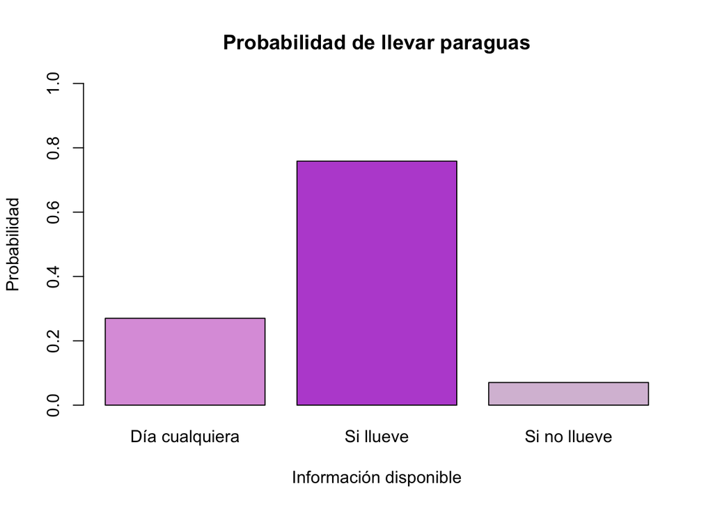

```r
barplot(valores,
        names.arg = nombres,
        ylim = c(0, 1),
        col = c("plum", "mediumorchid", "thistle"),
        main = "Probabilidad de llevar paraguas",
        xlab = "Información disponible",
        ylab = "Probabilidad")
```

**Para conversar**

¿Qué probabilidad es más alta?

¿Qué probabilidad es más baja?

¿Por qué cambia la probabilidad cuando sabemos si llueve o no?

# Cierre del taller

Durante este taller usamos programación, simulaciones y análisis de datos para explorar fenómenos aleatorios y responder preguntas usando probabilidades.

Aunque trabajamos con ejemplos simples, las ideas que usamos aparecen en muchos contextos reales:

- predicción del clima;
- salud pública;
- redes sociales;
- deportes;
- economía;
- física;
- videojuegos;
- química,
- ingeniería,
- entre otras.

Las probabilidades nos ayudan a tomar decisiones cuando existe incertidumbre.

Y R nos permite explorar preguntas, organizar información, hacer cálculos y visualizar patrones de manera dinámica.

**Mensaje final**

La matemática y la estadística consisten en hacer preguntas, explorar ideas, analizar información y descubrir patrones usando datos.

**Para seguir explorando**

Muchas áreas actuales utilizan probabilidades, estadística y programación.

La curiosidad, las preguntas y la creatividad son tan importantes como los cálculos.

Aprender R y aprender probabilidades puede abrir muchas puertas para entender mejor el mundo y participar en áreas científicas, tecnológicas y sociales.

Esperamos que este taller haya mostrado que la programación y las matemáticas pueden transformarse en herramientas para explorar el mundo, hacer preguntas interesantes y desarrollar nuevas ideas.